# Introduction

STAT 5840

Summer 2017

# Introduction

```r
library(ggplot2)
library(lattice)
library(distr)
```

## Likelihood Methods

Review: Maximum likelihood, Sir Ronald Aylmer Fisher (1921)

### Examples

#### Bernoulli.

Write $X \sim \mathrm{Bern}(p)$.
$$f(x|\theta) = \theta^{x}(1-\theta)^{1-x},\ x=0,1,\quad, 0 < \theta < 1.$$
The likelihood function is
$$\begin{eqnarray*}
L(\theta) & = & \prod_{i=1}^{n}\theta^{x_{i}}(1-\theta)^{1-x_{i}}\\
& = & \theta^{\sum x_{i}}(1-\theta)^{n-\sum x_{i}},\quad0<\theta<1.
\end{eqnarray*}$$

If $n = 5$ and $x = (1,0,1,1,0)$, then $\sum x_{i}=3$ and $n - \sum x_{i}=2$.

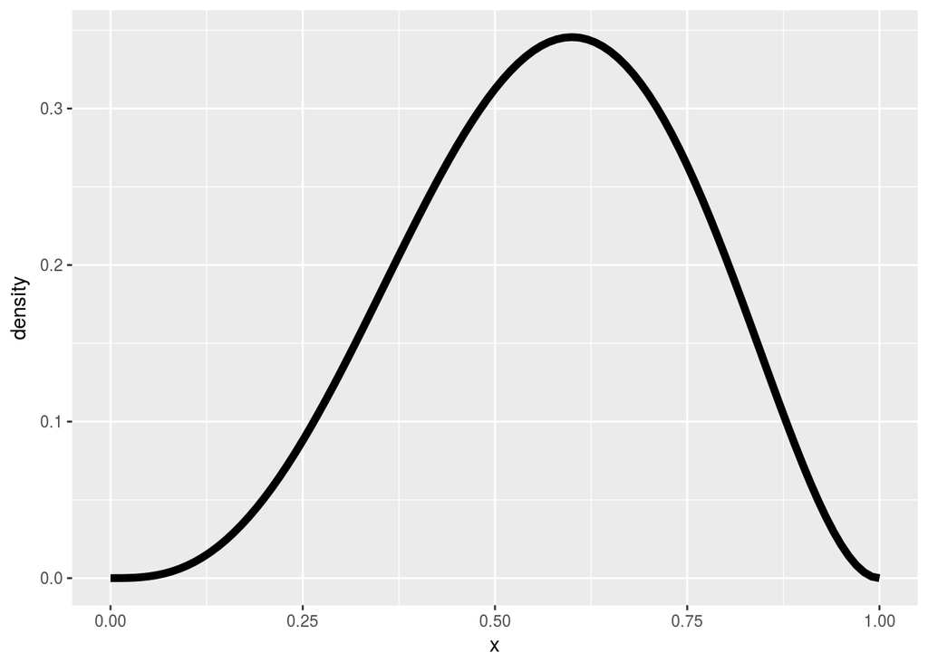

Likelihood function for a binomial experiment

```r
f <- function(x) dbinom(3, size = 5, prob = x)
p0 <- qplot(0:1, geom = 'blank') +
      labs(x = "x", y = "density") +
      stat_function(fun = f, lwd = 2)
print(p0)
```

#### Normal.

Write $X\sim N(\mu,\sigma^2)$. Then
$$f(x|\theta) = \frac{1}{\sigma\sqrt{2\pi}}\exp\left[\frac{-(x-\mu)^{2}}{2\sigma^{2}}\right],\quad-\infty<x<\infty.$$
Here $\theta = (\mu,\sigma^2)$. The likelihood function is
$$\begin{eqnarray*}
L(\theta) & = & \prod_{i=1}^{n}\frac{1}{\sigma\sqrt{2\pi}}\exp\left[\frac{-(x_{i}-\mu)^{2}}{2\sigma^{2}}\right]\\
& = & (2\pi\sigma^{2})^{-n/2}\exp\left[-\frac{1}{2\sigma^{2}}\sum_{i=1}^{n}(x_{i}-\mu)^{2}\right],
\end{eqnarray*}$$

for $-\infty < \mu < \infty$ and $\sigma > 0$.

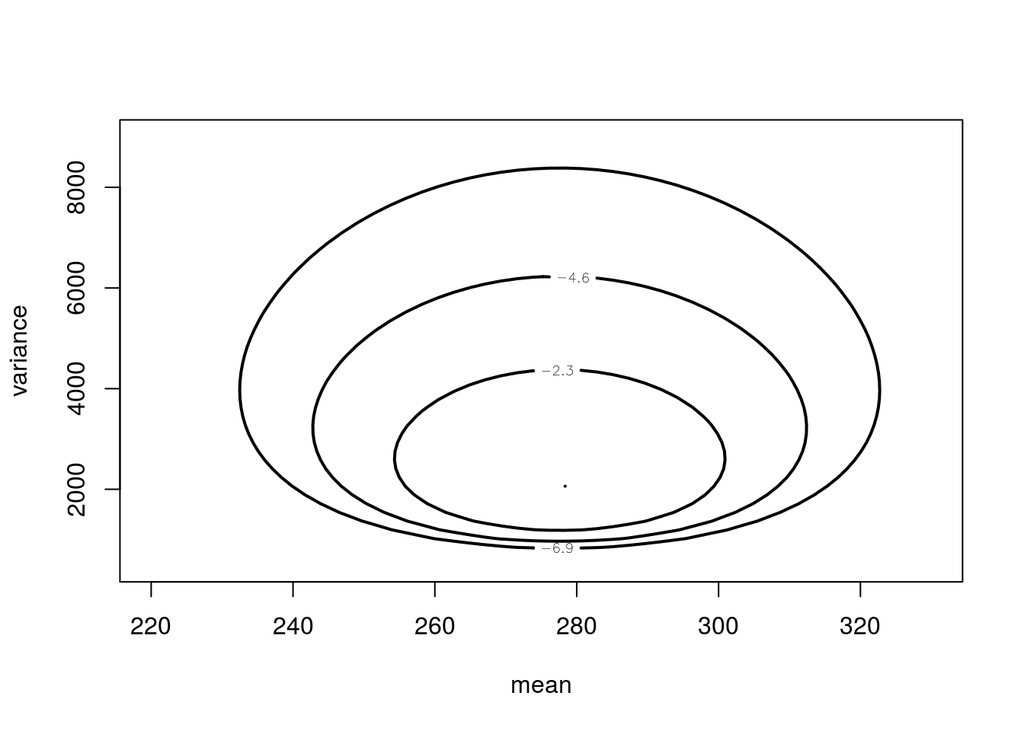

```r
library(LearnBayes)
data(marathontimes)
attach(marathontimes)
mycontour(normchi2post, c(220, 330, 500, 9000), time, xlab="mean",ylab="variance")
```

### Statistical Inference

#### Point estimation: maximize $L(\theta)$ to get $\hat{\theta}$.

- $\hat{\theta}$ is called an “MLE”.

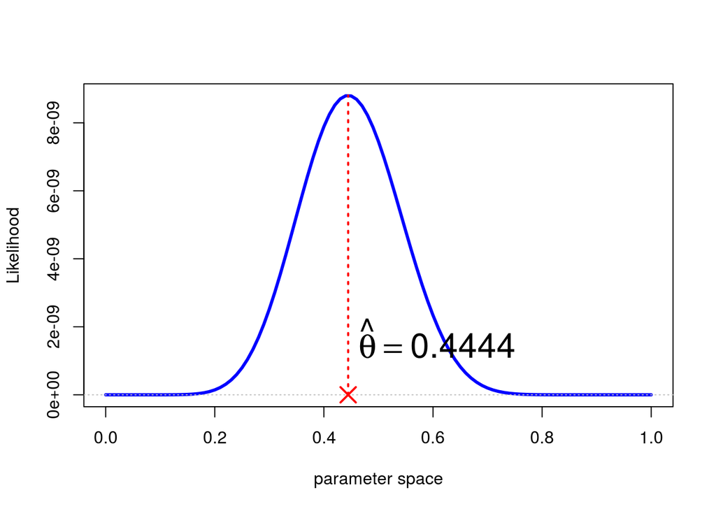

```r
dat <- rbinom(27, size = 1, prob = 0.3)
like <- function(x){
  r <- 1
  for (k in 1:27){
    r <- r*dbinom(dat[k], size = 1, prob = x)
  }
  return(r)
}
curve(like, from = 0, to = 1, xlab = "parameter space",
      ylab = "Likelihood", lwd = 3, col = "blue")
abline(h = 0, lwd = 1, lty = 3, col = "grey")
mle <- mean(dat)
mleobj <- like(mle)
lines(mle, mleobj, type = "h", lwd = 2, lty = 3, col = "red")
points(mle, 0, pch = 4, lwd = 2, cex = 2, col = "red")
text(mle, mleobj/6, substitute(hat(theta)==a,
     list(a=round(mle, 4))), cex = 2, pos = 4)
```

#### Interval estimation: use

$$\hat{\theta} \pm z_{\alpha/2}\cdot \sigma_{\hat{\theta}},$$
where $\sigma_{\hat{\theta}}$ is the standard error of $\hat{\theta}$ which is $\sqrt{\mathrm{Var}(\hat{\theta})}$.

- Usually we don’t know $\sigma_{\hat{\theta}}$. We approximate it.
- If $l(\theta) = \log L(\theta)$ then when $n$ is large
  $$\mathrm{Var}(\hat{\theta}) \approx -\frac{1}{l''(\hat{\theta})}.$$
- From a higher class… MLEs are aymptotically efficient; use the Delta method.

### Examples of MLEs

#### Bernoulli

$$\begin{eqnarray*}
L(\theta) & = & \prod_{i=1}^{n}\theta^{x_{i}}(1-\theta)^{1-x_{i}}\\
& = & \theta^{\sum x_{i}}(1-\theta)^{n-\sum x_{i}},\quad0<\theta<1.
\end{eqnarray*}$$

$$\mathrm{MLE} = \hat{\theta} = \frac{\sum x_{i}}{n} = \overline{x}.$$

$$\begin{eqnarray*}
L(\theta) & = & \prod_{i=1}^{n}\frac{1}{\sigma\sqrt{2\pi}}\exp\left[\frac{-(x_{i}-\mu)^{2}}{2\sigma^{2}}\right]\\
& = & (2\pi\sigma^{2})^{-n/2}\exp\left[-\frac{1}{2\sigma^{2}}\sum_{i=1}^{n}(x_{i}-\mu)^{2}\right],
\end{eqnarray*}$$

Can show (see 5844/6944 book)
$$\frac{\partial}{\partial\mu}l(\theta) = 0 \mbox{ has solution } \hat{\mu}=\overline{x},$$
$$\frac{\partial}{\partial\sigma^{2}}l(\theta) = 0 \mbox{ has solution } \hat{\sigma^{2}}=\frac{1}{n}\sum_{i=1}^{n}(x_{i} - \overline{x})^{2}.$$

That is, $\hat{\theta} = \left(\overline{x},\,n^{-1}\sum_{i=1}^{n}(x_{i} - \overline{x})^{2}\right)$. JOINT MLE.

#### Beta - harder situation, but still possible.

Write $X \sim \mathrm{Beta}(\alpha,\beta)$.
$$\begin{equation}
f_{X}(x)=\frac{\Gamma(\alpha+\beta)}{\Gamma(\alpha)\Gamma(\beta)}\: x^{\alpha-1}(1-x)^{\beta-1},\quad0 < x <1,
\end{equation}$$
where $\alpha > 0$ and $\beta > 0$ and
$$\begin{equation}
\Gamma(\alpha)=\int_{0}^{\infty}x^{\alpha-1}\mathrm{e}^{-x}\:\mathrm{d} x,\quad\mbox{for }\alpha>0.
\end{equation}$$

- Pictures of some Betas.

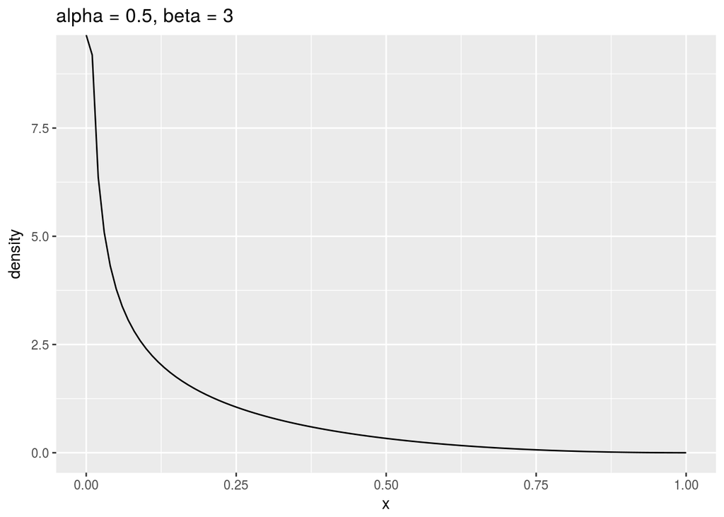

Pictures of some Beta distributions

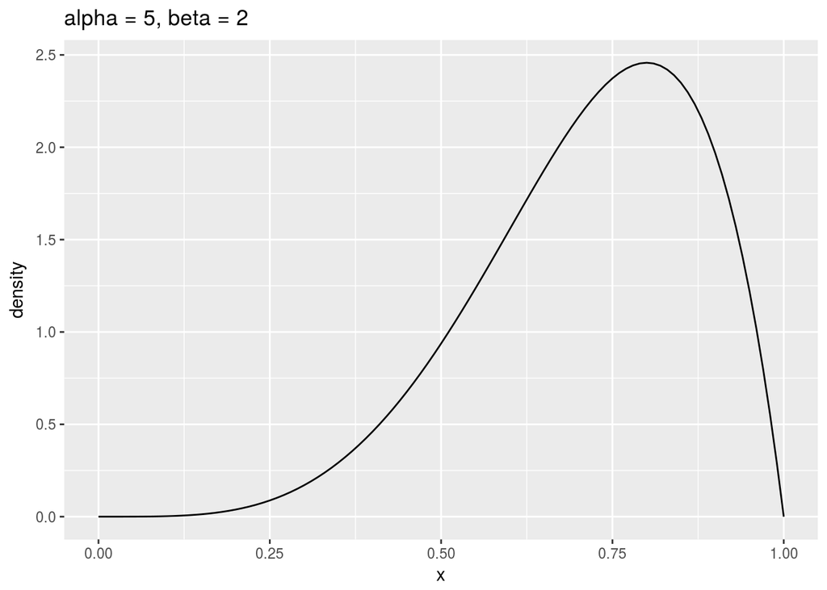

Pictures of some Beta distributions

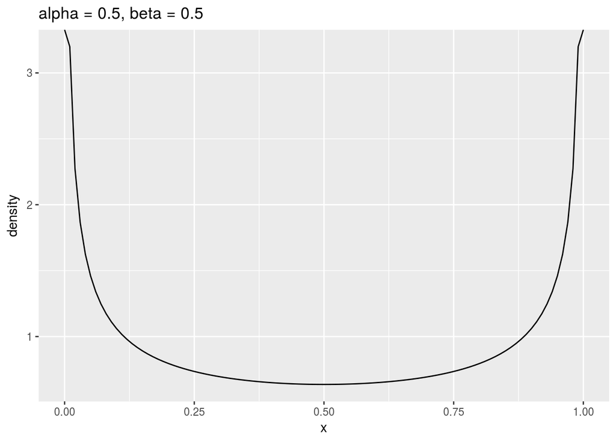

Pictures of some Beta distributions

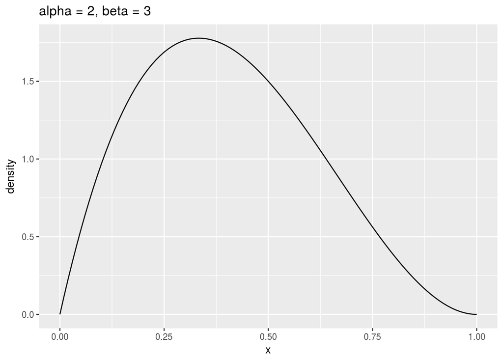

Pictures of some Beta distributions

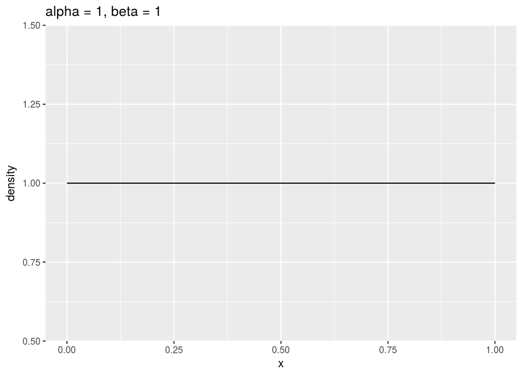

Pictures of some Beta distributions

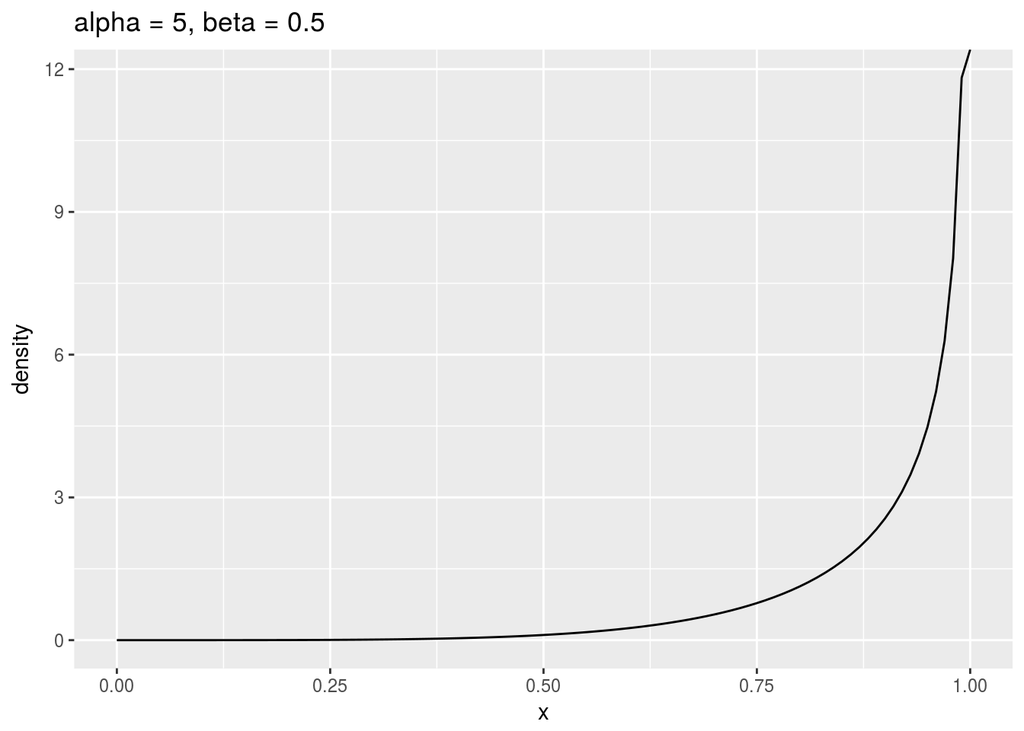

Pictures of some Beta distributions

```r
a <- matrix(c(0.5, 2, 5, 1, 0.5, 5), nrow = 2)
b <- matrix(c(3, 3, 2, 1, 0.5, 0.5), nrow = 2)
for (i in seq.int(2)){
  for (j in seq.int(3)){
    f <- function(x) dbeta(x, shape1 = a[i,j], shape2 = b[i,j])
    tmp <- qplot(0:1, geom = 'blank',
                 main = paste("alpha = ", a[i,j], ", beta = ", b[i,j], sep = "")) +
           labs(x = "x", y = "density") +
           stat_function(fun = f)
    print(tmp)
  }
}
```

Then
$$L(\theta) = \prod_{i=1}^{n}\frac{\Gamma(\alpha+\beta)}{\Gamma(\alpha)\Gamma(\beta)}\: x_{i}^{\alpha-1}(1-x_{i})^{\beta-1}, \quad \alpha > 0,\ \beta > 0.$$

The likelihood equations simplify to
$$\begin{cases}
\frac{1}{n}\sum\ln x_{i} & =\Psi(\alpha)-\Psi(\alpha+\beta),\\
\frac{1}{n}\sum\ln(1-x_{i}) & =\Psi(\beta)-\Psi(\alpha+\beta),
\end{cases}$$
where $\Psi(z)=\Gamma'(z)/\Gamma(z)$ is the *digamma* function.

- This looks hard!
- analytically impossible
- numerically trivial.

## Why are we in Statistical Computing?

Likelihood functions can be complicated!

### Censored or missing data

- Data are right censored, say, we are doing a study about the effectiveness of a drug on a disease.
- Let $X_{i} =$ time until onset of disease for $i^{\mathrm{th}}$ patient, $i=1,\ldots,n$.
- Suppose $X_{1},\ldots X_{n}$ are IID
  $$f(x|\theta),\quad \mbox{``survival density''}\quad \mathrm{PDF}$$
  $$F(x|\theta),\quad \mbox{``survival CDF''},\quad =\int_{-\infty}^{x}f(t|\theta)\mathrm{d} t$$
- However, the length of the study is LIMITED to $c$ duration (*e.g.* $c=5$ years).
- The data are $X_{1},\ldots X_{n}$, but we actually observe
  $$Y_{i}=
  \begin{cases}
  X_{i}, & \mbox{if }X_{i}<c,\\
  c, & \mbox{if }X_{i}\geq c.
  \end{cases}$$

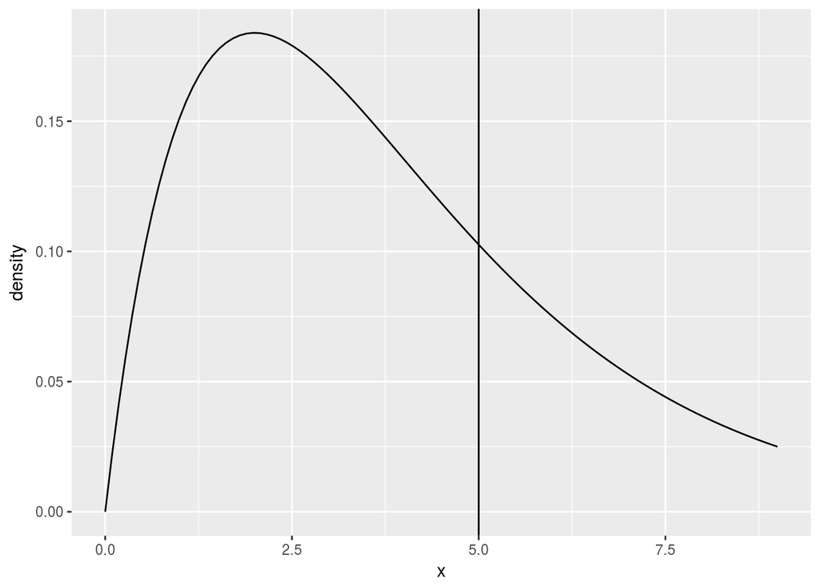

```r
f <- function(x) dchisq(x, df = 4)
p0 <- qplot(0:9, geom = 'blank') +
      labs(x = 'x', y = 'density') +
      stat_function(fun = f) +
      geom_vline(xintercept = 5)
print(p0)
```

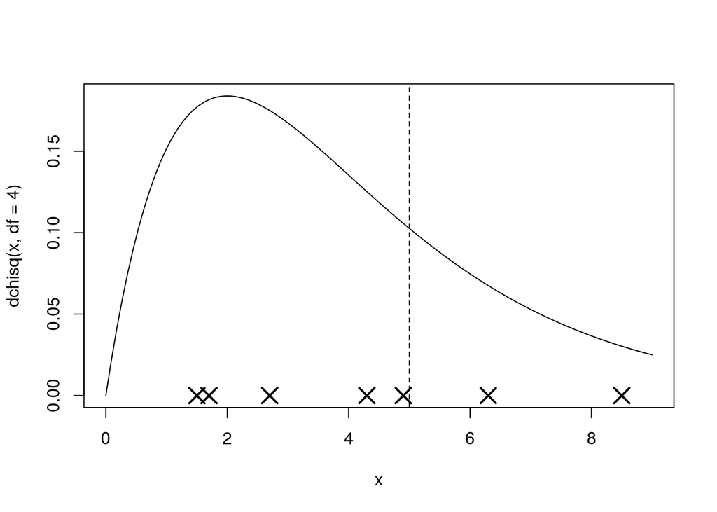

```r
curve(dchisq(x, df = 4), xlim = c(0,9))
abline(v = 5, lty = 2)
points(c(1.5, 1.7, 2.7, 4.3, 4.9, 6.3, 8.5), rep(0,7), pch = 4, lwd = 2, cex = 2)
```

- Likelihood function
  $$L(\theta | y_{1},\ldots,y_{n}) = \prod_{y_{i} < c} f(y_{i}|\theta)\cdot \prod_{y_{i}\geq c}\left[ 1 - F(c|\theta) \right]$$
- This is a typical/common problem. We will return often.

### Robust modelling/Likelihood can be multimodal

- Typically we assume $X_{1},\ldots X_{n}$ are IID $N(\mu,\sigma^{2})$.
- Then $L(\mu,\sigma^{2}) =$ EASY. $\hat{\mu} = \overline{x}$.
- Is this always appropriate? NO! Why?

#### Alternative (Nonnormal) Models

Often we have heavy-tailed distributions.

- Student’s *t* distribution. $T(r,\mu,\sigma^2)$
  $$\begin{equation}
  f(x)=\frac{\Gamma\left[(r+1)/2\right]}{\sigma\sqrt{r\pi}\,\Gamma(r/2)}\left(1+\frac{(x - \mu)^{2}}{\sigma^{2}r}\right)^{-(r+1)/2},\quad-\infty<x<\infty,
  \end{equation}$$
  where $-\infty < \mu < \infty$, $\sigma > 0$, and $r = 1, 2,\ldots$ are the *degrees of freedom*.

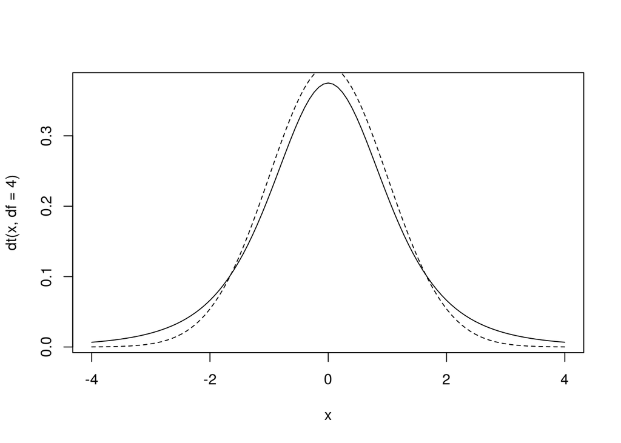

```r
curve(dt(x, df = 4), xlim = c(-4,4))
curve(dnorm(x), lty = 2, add = TRUE)
```

- We see that
$$\begin{equation}
f(x) \propto \sigma^{-1}\left(1+\frac{(x - \mu)^{2}}{\sigma^{2}r}\right)^{-(r+1)/2},
\end{equation}$$

- Usually $r$ is known and $\mu,\sigma^{2}$ are unknown.
- Given SRS $X_{1},\ldots X_{n}$, the likelihood is
  $$\begin{align*}
  L(\mu,\sigma^{2}) & = \prod \sigma^{-1}\left(1+\frac{(x_{i} - \mu)^{2}}{\sigma^{2}r}\right)^{-(r+1)/2}\\
  & = \sigma^{-n} \left[\prod \left(1+\frac{(x_{i} - \mu)^{2}}{\sigma^{2}r}\right) \right]^{-(r+1)/2}
  \end{align*}$$
- For fixed $\sigma$, by playing with the data one can choose the number of modes of the likelihood. Notice the inside is a polynomial in $\mu$ of degree $2n$. It may have many (up to $n$) minima. Then the likelihood has $n$ maxima, each of which has to be checked. As $n \to \infty$, this is very difficult.
- Cauchy distribution (take $r = 1$ in Student’s *t*).
- Write $X_{1},\ldots X_{n} \sim \mathrm{Cauchy}(m,\sigma)$, where $m$ is the median and $\sigma$ is a scale parameter.
- The PDF is
  $$\begin{equation}
  f(x|m,\sigma)=\frac{1}{\sigma\pi}\left[1+\left(\frac{x-m}{\sigma}\right)^{2}\right]^{-1},\quad -\infty < x <\infty,
  \end{equation}$$
  where $-\infty < m < \infty$ and $\sigma > 0$.
- We use the median and scale parameter because the mean and variance DNE! (it’s *very* heavy-tailed.)

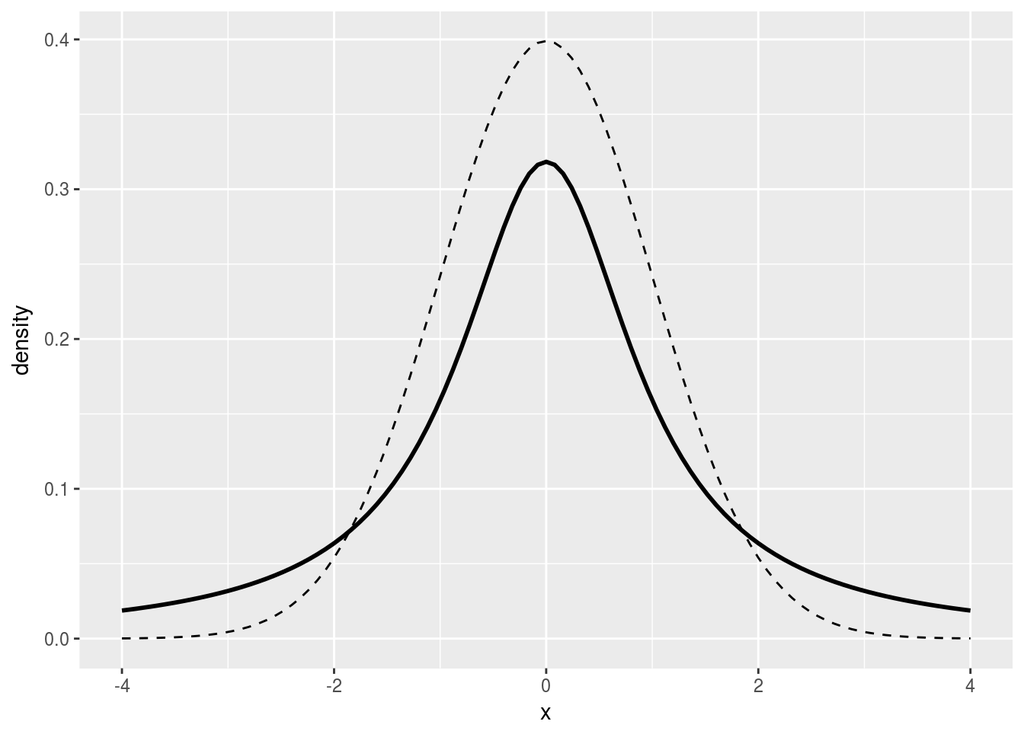

```r
library(ggplot2)
p1 <- qplot(-4:4, geom = 'blank', xlab = "x", ylab = "density") +
      stat_function(fun = dnorm, lty = 2) +
      stat_function(fun = dcauchy, lwd = 1)
print(p1)
```

- Double Exponential (AKA Laplace).
  $$\begin{equation}
  f(x|\mu,\sigma)=\frac{1}{2\sigma}\exp\left(-\frac{|x - \mu|}{\sigma}\right),\quad -\infty < x <\infty,
  \end{equation}$$
  where $-\infty < \mu < \infty$ and $\sigma > 0$.
- the MLE is $\hat{\mu} = \text{sample median}$

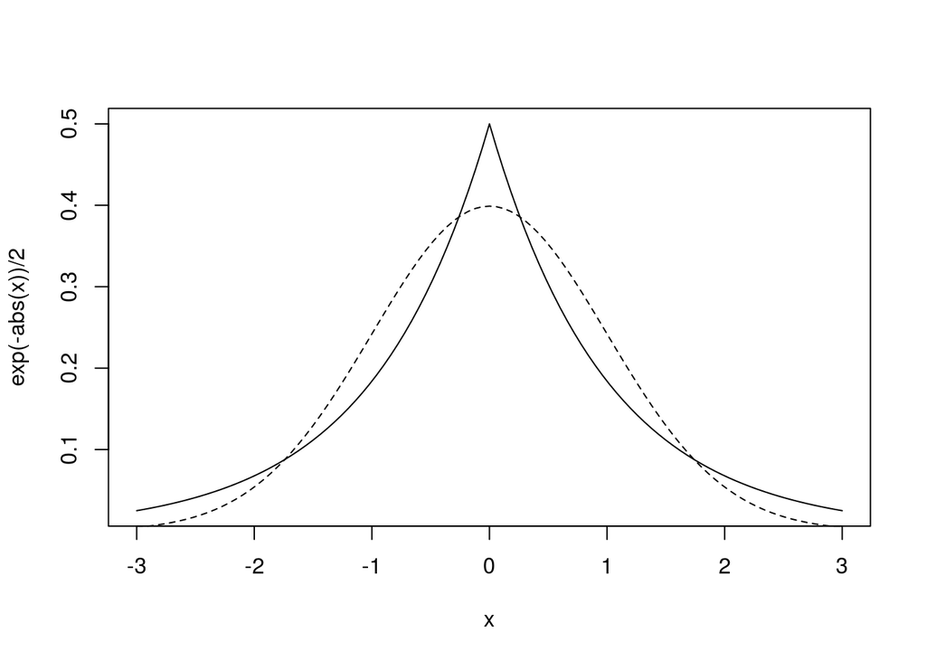

```r
curve(exp(-abs(x))/2, xlim = c(-3,3))
curve(dnorm(x), lty = 2, add = TRUE)
```

### Mixture distributions

Here we have $X_{1},\ldots, X_{n} \sim f(x|\theta)$, but $f$ takes the form
$$f(x|\theta) = \sum_{j=1}^{k}p_{j}f_{j}(x|\theta_{j}),$$
where $p_{j}\geq 0$ and $\sum_{j}p_{j}=1$.

- Have $k$ different groups/subpopulations
- the proportion of people in group $j$ is $p_{j}$
- the $j^{\mathrm{th}}$ subpop. has distribution $f_{j}(\cdot |\theta_{j})$

#### Example: Studying heights of students

- Let $X = \mbox{height in inches}$.
- Male heights $\approx N(71, 3^2)$
- Female heights $\approx N(63, 2^2)$
- Suppose there are 66% males, 34% females

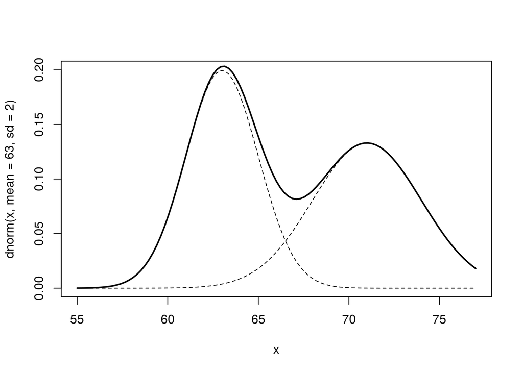

```r
curve(dnorm(x, mean = 63, sd = 2), xlim = c(55, 77), ylim = c(0, 0.2), lty = 2)
curve(dnorm(x, mean = 71, sd = 3), add = TRUE, lty = 2)
f <- function(x) dnorm(x, mean = 63, sd = 2) + dnorm(x, mean = 71, sd = 3)
curve(f, lwd = 2, add = TRUE)
```

Then the population density is

$$\begin{eqnarray*}
f(x) & = & p\,N(\mu_{1},\sigma_{1}^{2}) + (1 - p)\,N(\mu_{2},\sigma_{2}^{2})\\
& \approx & 0.66\,f(x|71, 3^{2}) + 0.34\,f(x|63,2^{2})
\end{eqnarray*}$$

In general, the likelihood is

$$\begin{eqnarray*}
L(\theta) & = & \prod_{i=1}^{n} \left( \sum_{j=1}^{k}p_{j}f_{j}(x_{i}|\theta_{j}) \right) \\
& = & \prod_{i=1}^{n} \left( p_{1}f_{1}(x_{i}|\theta_{1}) + \cdots + p_{1}f_{k}(x_{i}|\theta_{k}) \right)
\end{eqnarray*}$$

The product, when expanded, will have $k^{n}$ terms. This explodes as $n \to \infty$, so not only do we have multimodality, we have SMALL RESOURCES, too.

### Dependent Bernoulli trials

YET ANOTHER MODEL!

- Coin tossing model: $X_{1},\ldots, X_{n}$ IID Bern($p$), where
- $\Pr(\mbox{success}) = p$, constant, and
- the trials are independent.

#### BUT -

- Maybe the $p$’s change across trials
- Maybe there is dependence in the sequence

Suppose we have belief in STREAKY behavior - Two (2) states: - $p_{H} \to \mbox{hot state}$ - $p_{C} \to \mbox{cold state}$

If you are hot, you are more likely to stay hot in the next trial…

[output not shown]

- We don’t know: $p_{H}$, $p_{C}$, $a$.
- Observe a vector of $X$’s, for example,
  $$x = (1,1,1,0,0,1,0,0,0,1,0,0,1,1,1)$$
- One possible configuration of states
  $$s = (H,H,H,C,C,H,C,C,C,H,C,C,H,H,H)$$
- Probability in this configuration would be
  $$\frac{1}{2}p_{H}ap_{H}ap_{H}a(1-a)p_{C}(1-a)p_{C}\cdots$$

The Likelihood is
$$L(p_{H},p_{C},a) = \sum_{\mbox{all possible configurations}}\Pr(\mbox{observe $x$}|\mbox{state is $s$})$$
- AKA “Markov Switching Model” - Number of terms in above sum: $2^{n}$ - very complicated.

## Introduction to Bayesian Statistics

- Named for Reverend Thomas Bayes (1702-1761)
- Based on the theory of subjective probability

### Central Theme

- the quantity of interest, $\theta$, is unknown and considered to be a *random variable*.
- we have beliefs / existing knowledge about $\theta$, represented by
  $$\pi(\theta) \leadsto \text{the PRIOR distribution of } \theta.$$
- $\pi$ is a PDF, nonnegative, integral one. We wish to learn about $\theta$! To this end we conduct an experiment, and consequently we observe a random variable $X$ which depends (in some way) on $\theta$. The conditional distribution of $X$ given $\theta$ is represented by
  $$f(x|\theta) \leadsto \text{ the LIKELIHOOD function}.$$
  We wish to UPDATE our beliefs about $\theta$, using the information contained in the observation $X=x$ combined with our prior beliefs. Our new beliefs will be represented by
  $$\pi(\theta|x) \leadsto \text{the POSTERIOR distribution of }\theta.$$
- Method: :: BAYES’ RULE

$$\pi(\theta|x)=\frac{f(x|\theta)\, \pi(\theta)}{\int f(x|\theta)\, \pi(\theta)
\mathrm{d} \theta}, \quad \mbox{for $\theta \in \Theta$.}$$

#### Remarks:

- Once beliefs are updated, we then go out and do another experiment to learn even more! Update again. Schematic Diagram.
- From Bayes’ Rule
  $$\begin{align*}
  \pi(\theta|x)&=\frac{f(x|\theta)\, \pi(\theta)}
  {\int f(x|\theta)\, \pi(\theta)d\theta}\\
  &= M \, f(x|\theta)\, \pi(\theta)\\
  &\propto f(x|\theta)\, \pi(\theta).
  \end{align*}$$

  Hence, Bayes’ Rule is often written in the form POSTERIOR $\propto$ LIKELIHOOD $\times$ PRIOR
- Notice the difference in interpretations: For a Frequentist:
  $$\mbox{LIKELIHOOD}=L(\theta)=f(\mathbf{x}|\,\theta)= \mbox{a function of $\theta$}.$$
  While for a Bayesian:
  $$\mbox{LIKELIHOOD}=f(\mathbf{x}|\,\theta)= \mbox{a function of $\mathbf{x}$}.$$

#### Examples.

Want to learn about
$$p = \mbox{proportion of goldfish in lake}$$

1. Construct a continuous prior for $p$.

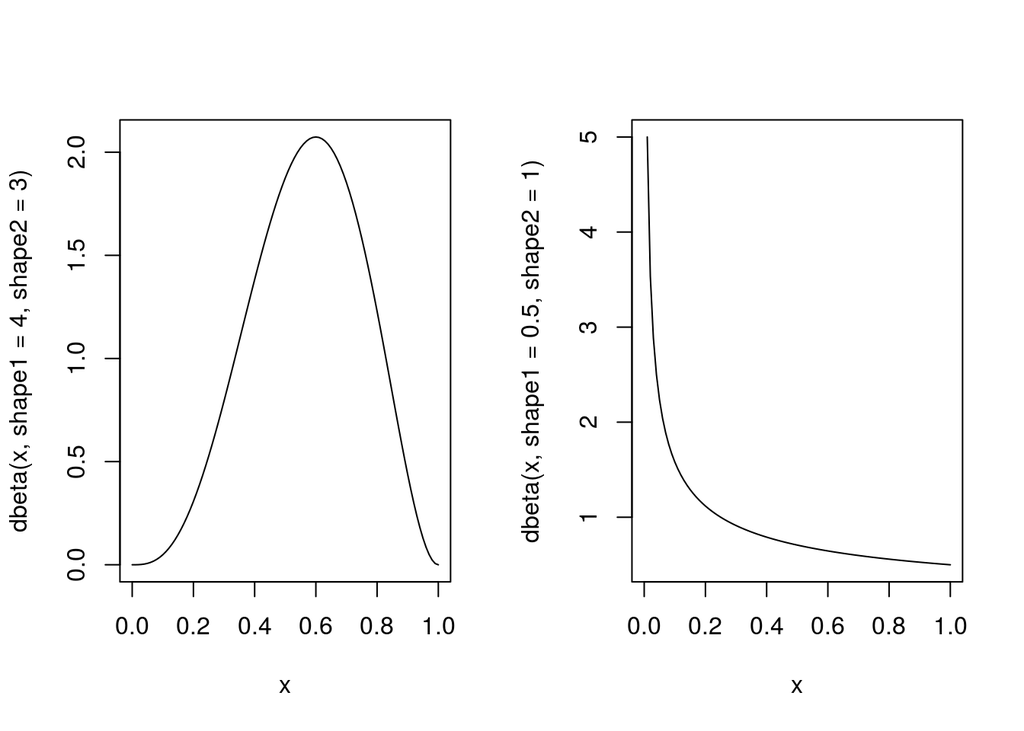

```r
par(mfrow = c(1,2))
curve(dbeta(x, shape1 = 4, shape2 = 3))
curve(dbeta(x, shape1 = 0.5, shape2 = 1))
```

```r
par(mfrow = c(1,1))
```

Let $p$ have a Beta density,
$$\begin{equation}
p \sim \pi(p)=\frac{\Gamma(\alpha+\beta)}{\Gamma(\alpha)\Gamma(\beta)}\: p^{\alpha-1}(1-p)^{\beta-1},\quad 0 < p < 1. \quad \mbox {This is the prior.}
\end{equation}$$

*Summary:* - Started with prior, $p \sim \mathrm{Beta}(\alpha,\beta).$ - Did experiment, observed $Y = y$. - Get posterior, $p|y \sim \mathrm{Beta}(\alpha + y,\ \beta + n - y).$

### Bayesian Statistics

Draw all inference from the posterior distribution $\mathrm{Beta}(\alpha + y,\ \beta + n - y)$.

Our new guess at $p$:
$$\begin{align*}
\eta^{\ast} &= \frac{\alpha^{\ast}}{\alpha^{\ast}+\beta^{\ast}} \\
&= \frac{\alpha + y}{(\alpha + y) + (\beta + n - y)} \\
&= \frac{\alpha + y}{\alpha + \beta + n} \\
&= \frac{\alpha}{\alpha + \beta + n}\cdot\frac{\alpha + \beta}{\alpha + \beta} + \frac{y}{\alpha + \beta + n}\cdot\frac{n}{n} \\
&= \frac{\alpha}{\alpha + \beta}\cdot\frac{\alpha + \beta}{\alpha + \beta + n} + \frac{y}{n}\cdot\frac{n}{\alpha + \beta + n} \\
&= \eta\cdot\frac{\kappa}{\kappa + n} + \frac{y}{n}\cdot\frac{n}{\kappa + n}
\end{align*}$$

That is, the POSTERIOR MEAN is a *weighted average* or the MLE and the PRIOR MEAN. It’s called a *shrinkage estimator*.

- As $\kappa \to \infty$, we have $\eta^{\ast} \to \eta$.
- As $n \to \infty$, we have $\eta^{\ast} \to \mathrm{MLE}$.

*Remarks:*

#### How do we choose a prior?

Notice: - Prior $\to$ Beta - Posterior $\to$ Beta, too.

$\mathrm{Beta}(\alpha,\beta)$ is called a CONJUGATE FAMILY.

Beta/Binomial is called a CONJUGATE PAIR.

Another conjugate pair: if $\pi(\theta) = N(\mu,\,\tau^{2})$ and $f(x|\theta) = N(\theta,\,\sigma^{2})$, then
$$\pi(\theta|x) = N\left(\frac{\overline{x}\tau^{2}+\mu\sigma^{2}/n}{\tau^{2}+\sigma^{2}/n},\,\frac{\tau^{2}\cdot\sigma^{2}/n}{\tau^{2}+\sigma^{2}/n} \right).$$

- Other pairs:
- Gamma/Normal
- Gamma/Poisson
- Gamma/Gamma

Here, $\mathrm{Gamma}(\alpha,\beta)$ has PDF
$$f(x|\alpha,\beta) = \frac{1}{\Gamma(\alpha)\beta^{\alpha}}\,x^{\alpha - 1} \mathrm{e}^{-x/\beta},\ x > 0,$$
where $\alpha > 0$ and $\beta > 0$.

Special cases: - $\mathrm{Exp}(\beta) = \mathrm{Gamma}(1,\beta)$ - Chi-square $\chi^{2}(\nu) = \mathrm{Gamma}(\nu/2,\,2),\ \nu =1,2,\ldots$

Conjugate families were chosen for priors historically because they are tractable, convenient, easy. Turns out, conjugate families are *very* restricted (that is, most families of priors are not conjugate). This used to be a problem, but computing advances have made this last difficulty negligible.

#### Bayesian Point Estimation

Our new guess at $\theta$: the POSTERIOR MEAN $\E [\theta|x]$.

Fact: the posterior mean is optimal in almost every sense, under the assumption of *squared error loss*.

The squared error loss of an estimator $\delta$ which estimates $\theta$ is
$$L(\delta,\theta) = (\delta - \theta)^{2}.$$

We will often need to compute the posterior mean. Therefore we will need to compute things like
$$\begin{align*}
\E [\theta|x] &= \int \, \theta\, \pi(\theta|x)\,\mathrm{d} \theta, \\
&= \int \frac{\theta\, f(x|\theta)\,\pi(\theta)}{\int f(x|u)\pi(u)\mathrm{d} u} \,\mathrm{d} \theta, \\
&= M \cdot \int \theta f(x|\theta)\pi(\theta)\,\mathrm{d} \theta.
\end{align*}$$

This will often be complicated, with no closed form solution. Therefore we will need to resort to computing techniques.

#### Bayesian Interval Estimation

Here we have a probability interval of probability content $\gamma$, AKA “credible regions”.

The Bayesian has many options:

- Equal-Tails interval
- Shortest interval of content $\gamma$, or “HDR (highest density region)” interval

Since posteriors are often complicated, calculation of credible regions is difficult and we need Monte Carlo techniques.